# 02-Modular-Design

One of the most important techniques for managing software complexity is to design systems so that developers only need to face a small fraction of the overall complexity at any given time. One approach to doing this is called *modular design*.

In modular design, a software system is decomposed into a collection of modules that are relatively independent. Modules can take many forms in different languages. For our purposes, we can think of a module as a single Python class (note how we're not referring to "Python modules"; we're using the term "module" more generically)

Modules should be relatively independent, but can't be completely independent. For example, I could have a `Graph` class that relies on a `PriorityQueue` class to run Dijkstra's algorithms. Also, recall that, in Dijkstra's Algorithm, we could insert values into the priority queue, but might also need to update an existing priority.

So, let's say `PriorityQueue` has an `insert` method that looks like this:

```
def insert(self, priority: int, item: str)
```

As its name suggests, this method will insert an `item` in the priority queue with a given `priority`. However, let's say this method pulls double-duty: if we specify an `item` that is already in the priority queue, the item's priority is updated.

However, at some point, the developer of `PriorityQueue` decides they want to separate the `insert` method into two methods: `insert` (which only does insertions, and will fail if we try to insert the same value more than once) and `change_priority`, which will change the priority of an existing method. The `Graph` code that uses the `PriorityQueue` class would stop working, and would have to be updated to use the new functions.

Again, these dependencies are unavoidable (we wouldn't solve this issue by severing ties with `PriorityQueue` entirely). However, we can better manage these dependencies by dividing modules into two parts: the interface and the implementation.

- **Interface**: What other developers see (and what they need to know about the module). Focuses on "what" not "how".
- **Implementation**: How the module carries out the promises made in the interface.

While some languages (like Java and C++) will allow you to define an interface separate from the implementation, Python makes no such distinction. The specification of a class's interface is often a matter of documentation, and not so much of code (except for one aspect we describe below.)

## Example: The `AVLTree` class

Consider the following simplified `AVLTree` class, where we have omitted the body of the methods (and replaced them with `raise NotImplementedError`)

```python
from typing import Optional

class AVLTree:
    _value: int
    _left: Optional["AVLTree"]
    _right: Optional["AVLTree"]

    # Constructor
    def __init__(self, value: int):
        self._value = value
        self._left = None
        self._right = None

    # Public methods

    @property
    def value(self) -> int:
        return self._value

    @property
    def num_nodes(self) -> int:
        # Recursively compute the number of nodes
        raise NotImplementedError

    def contains(self, n: int) -> bool:
        raise NotImplementedError

    def insert(self, n: int) -> None:
        raise NotImplementedError

    # Private methods

    @property
    def _height(self) -> int:
        raise NotImplementedError

    @property
    def _balance_factor(self) -> int:
        raise NotImplementedError

    @property
    def _left_heavy(self) -> bool:
        raise NotImplementedError

    @property
    def _right_heavy(self) -> bool:
        raise NotImplementedError

    def _rot_right(self) -> None:
        raise NotImplementedError

    def _rot_left(self) -> None:
        raise NotImplementedError
```

Remember that, in Python, any method or attribute that starts with an underscore is, by convention, meant to be *private*. i.e., it is only meant to be accessed inside the `AVLTree` class, and not by anyone who is using the `AVLTree` class.

The interface of a class includes only its public methods and attributes. For `AVLTree`, that would be:

- Attributes: none (notice how we've made `value`, `left` and `right` private)
- Methods
  - `__init__(self, value: int)`
  - `num_nodes(self) -> int` (property)
  - `value(self) -> int` (property)
  - `contains(self, n: int) -> bool`
  - `insert(self, n: int) -> None`

When using this module (the `AVLTree` class), you only need to understand its interface, not its implementation. The implementation includes the contents of the public methods, as well as any private attributes and methods. The interface is an *abstraction* over the implementation. An abstraction is a simplified view of an entity, which omits unimportant details.

For example, someone who is using our `AVLTree` class does not need to understand the rotation operations, or even know they exist (including those methods in the interface would increase the cognitive load of our module). Similarly, they don't need to know about the attributes that are used to store the data internally. Another benefit of keeping these private is that it prevents improper manipulations of the tree (we don't want someone modifying the value of a node in a way that breaks the BST condition, for example).

**Q**: Earlier we said that this separation helps us manage dependencies. Why do you think that is?

**A**: The example we gave involved changing the semantics of an existing method that is part of the interface. This is a potentially disruptive change, because if I change the interface, everyone who uses my code has to adapt to that change.

Sometimes these kind of changes are necessary, but a clean separation between interface and implementation means that users of our code will (or should) be unaffected by changes in the *implementation* of the module.

For example, suppose that the `num_nodes` method computes the number of nodes recursively. Suppose we wanted to optimize this operation by, instead, having a private attribute `_num_nodes` that stores the number of nodes, and which gets updated any time we insert a value into the tree (this way, we don't have to recursively recompute the number of nodes; we can just return the value of `_num_nodes`).

If we made this change, we would just be changing the internal *implementation* of the tree. Anyone using the `AVLTree` class would continue to use the `num_nodes` property, and would be blissfully unaware that the implementation of that method had changed. In other words, users of the `AVLTree` class would be unaffected as long as the *interface* doesn't change. As long as we don't change the interface (which includes the expected behaviour of the functions), changes to `AVLTree` shouldn't affect the code that depends on `AVLTree`.

Along those lines, consider Python dictionaries. The *interface* of dictionaries is described in this page: https://docs.python.org/3/library/stdtypes.html#typesmapping We, as users of `dict` are blissfully unaware of everything that goes on inside the *implementation* of dictionaries. Internally, dictionaries use a data structure called a "hash table" but, if the Python developers decided to swap it out for a new data structure (let's say someone came up with a "hash hypertable" that performs 1000x better than a hash table), as long as the interface stays the same, all the code out there that depends on dictionaries would be unaffected.

## Deep Modules vs Shallow Modules

The best modules are the ones where the interface is much simpler than the implementation. Along those lines, we can characterize modules depending on whether they're "deep" or "shallow".

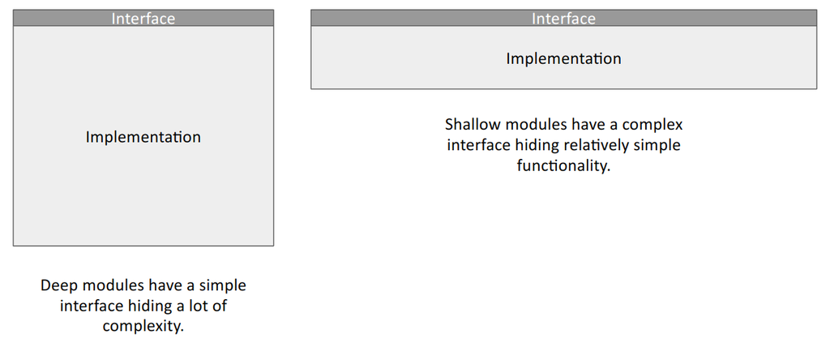

A deep module is one that provides powerful functionality with a simple interface.

A shallow module is one that provides an interface that is complicated relative to the provided functionality.

An example of a deep module is the File I/O functions in Python (or in any programming language, for that matter):

```python
f = open("file.txt")
txt = f.read()
print(txt)
f.close()
```

```
foo
bar
baz
```

Think about the huge amount of complexity that is hidden under those simple function calls:

- How do we go from "file.txt" to the exact location of the file in our hard drive?
- What if we specified directories? How are directory hierarchies implemented?
- Are we reading from a hard drive inside the computer? Are we reading from an external USB drive connected to the computer?

For example, suppose we are part of a project that is implementing a text-based game where the player writes commands like this:

```
WALK TO house
PICK UP box
OPEN door
GIVE love letter TO princess
```

A different team is in charge of implementing the user interface for this game, and their code will be responsible for actually getting these commands from the user. We will be responsible for processing them. We could design a class like this:

```
class GameLogic:

    ...

    def walk(self, destination):
        ...

    def pick_up(self, object):
        ...

    def open(self, object):
        ...

    def give(self, object, recipient):
        ...
```

While not a completely shallow module, this module could be deeper. The version above would require users to parse the command and separate it into its different components, which the user interface team arguably shouldn't be burdened with (their focus is on user interface, not on how the commands are meant to be processed, or the possible nuances in parsing them). We could hide more complexity by doing this:

```
class GameLogic:

    ...

    def process_command(self, cmd):
        ...
```

Which means that, once the user interface has received a command from the user, their code just needs to do a call like this:

```
game.process_command("GIVE love letter TO princess")
```

Note that this doesn't mean that the `walk`, `pick_up`, etc. methods shouldn't exist. However, an important design principle in modular design is to *pull complexity downwards*: The complexity of your module should reside in its implementation, not in its interface. So, `walk`, `pick_up`, etc. should instead be private methods ("implementation details") that the user of our module is unaware of.

**Simple interfaces are more important than a simple implementation**

Ousterhout also describes this (tongue-in-cheek) as "the martyr principle": it is better for a few developers of a module to "suffer", rather than thousands of users of that module. Hiding a lot of complexity inside a module (and figuring out how to keep the interface simple) involves tackling that complexity, which is hard, but doing so will make life easier for the users of your module.

Take into account that, in a real software project, your code will be read/used more often than it will be written/modified. Think of the developers that will come after you, not just about getting the job done as expeditiously as possible.